# Ford GoBike System Data

## Introduction

#### Ford GoBike is a regional public bicycle sharing system covering the greater part of San Francisco Bay area, and represents the first regional and large-scale bicycle sharing system deployed in California and on the West Coast of the United States.

#### In this project, data visulization will be performed by using univariate, bivariate, and multivariate plots to explore and gather more information about individual Ford GoBike user behaviours and preferences by studying trends, changes and differences in the month of February 2019.

## Preliminary Wrangling

```python
# import all packages and set plots to be embedded inline
import numpy as np
import pandas as pd
import matplotlib.pyplot as plt
import seaborn as sb
%matplotlib inline
```

```python
# Loading the dataset into a pandas dataframe
fordgobike= pd.read_csv('201902-fordgobike-tripdata.csv')
fordgobike.head(10)
```

|  | duration_sec | start_time | end_time | start_station_id | start_station_name | start_station_latitude | start_station_longitude | end_station_id | end_station_name | end_station_latitude | end_station_longitude | bike_id | user_type | member_birth_year | member_gender | bike_share_for_all_trip |
| --- | --- | --- | --- | --- | --- | --- | --- | --- | --- | --- | --- | --- | --- | --- | --- | --- |
| 0 | 52185 | 2019-02-28 17:32:10.1450 | 2019-03-01 08:01:55.9750 | 21.0 | Montgomery St BART Station (Market St at 2nd St) | 37.789625 | -122.400811 | 13.0 | Commercial St at Montgomery St | 37.794231 | -122.402923 | 4902 | Customer | 1984.0 | Male | No |
| 1 | 42521 | 2019-02-28 18:53:21.7890 | 2019-03-01 06:42:03.0560 | 23.0 | The Embarcadero at Steuart St | 37.791464 | -122.391034 | 81.0 | Berry St at 4th St | 37.775880 | -122.393170 | 2535 | Customer | NaN | NaN | No |
| 2 | 61854 | 2019-02-28 12:13:13.2180 | 2019-03-01 05:24:08.1460 | 86.0 | Market St at Dolores St | 37.769305 | -122.426826 | 3.0 | Powell St BART Station (Market St at 4th St) | 37.786375 | -122.404904 | 5905 | Customer | 1972.0 | Male | No |
| 3 | 36490 | 2019-02-28 17:54:26.0100 | 2019-03-01 04:02:36.8420 | 375.0 | Grove St at Masonic Ave | 37.774836 | -122.446546 | 70.0 | Central Ave at Fell St | 37.773311 | -122.444293 | 6638 | Subscriber | 1989.0 | Other | No |
| 4 | 1585 | 2019-02-28 23:54:18.5490 | 2019-03-01 00:20:44.0740 | 7.0 | Frank H Ogawa Plaza | 37.804562 | -122.271738 | 222.0 | 10th Ave at E 15th St | 37.792714 | -122.248780 | 4898 | Subscriber | 1974.0 | Male | Yes |
| 5 | 1793 | 2019-02-28 23:49:58.6320 | 2019-03-01 00:19:51.7600 | 93.0 | 4th St at Mission Bay Blvd S | 37.770407 | -122.391198 | 323.0 | Broadway at Kearny | 37.798014 | -122.405950 | 5200 | Subscriber | 1959.0 | Male | No |
| 6 | 1147 | 2019-02-28 23:55:35.1040 | 2019-03-01 00:14:42.5880 | 300.0 | Palm St at Willow St | 37.317298 | -121.884995 | 312.0 | San Jose Diridon Station | 37.329732 | -121.901782 | 3803 | Subscriber | 1983.0 | Female | No |
| 7 | 1615 | 2019-02-28 23:41:06.7660 | 2019-03-01 00:08:02.7560 | 10.0 | Washington St at Kearny St | 37.795393 | -122.404770 | 127.0 | Valencia St at 21st St | 37.756708 | -122.421025 | 6329 | Subscriber | 1989.0 | Male | No |
| 8 | 1570 | 2019-02-28 23:41:48.7900 | 2019-03-01 00:07:59.7150 | 10.0 | Washington St at Kearny St | 37.795393 | -122.404770 | 127.0 | Valencia St at 21st St | 37.756708 | -122.421025 | 6548 | Subscriber | 1988.0 | Other | No |
| 9 | 1049 | 2019-02-28 23:49:47.6990 | 2019-03-01 00:07:17.0250 | 19.0 | Post St at Kearny St | 37.788975 | -122.403452 | 121.0 | Mission Playground | 37.759210 | -122.421339 | 6488 | Subscriber | 1992.0 | Male | No |

```python
fordgobike.shape
```

```
(183412, 16)
```

```python
# Checking the statistics of columns with numerical values
fordgobike.describe()
```

|  | duration_sec | start_station_id | start_station_latitude | start_station_longitude | end_station_id | end_station_latitude | end_station_longitude | bike_id | member_birth_year |
| --- | --- | --- | --- | --- | --- | --- | --- | --- | --- |
| count | 183412.000000 | 183215.000000 | 183412.000000 | 183412.000000 | 183215.000000 | 183412.000000 | 183412.000000 | 183412.000000 | 175147.000000 |
| mean | 726.078435 | 138.590427 | 37.771223 | -122.352664 | 136.249123 | 37.771427 | -122.352250 | 4472.906375 | 1984.806437 |
| std | 1794.389780 | 111.778864 | 0.099581 | 0.117097 | 111.515131 | 0.099490 | 0.116673 | 1664.383394 | 10.116689 |
| min | 61.000000 | 3.000000 | 37.317298 | -122.453704 | 3.000000 | 37.317298 | -122.453704 | 11.000000 | 1878.000000 |
| 25% | 325.000000 | 47.000000 | 37.770083 | -122.412408 | 44.000000 | 37.770407 | -122.411726 | 3777.000000 | 1980.000000 |
| 50% | 514.000000 | 104.000000 | 37.780760 | -122.398285 | 100.000000 | 37.781010 | -122.398279 | 4958.000000 | 1987.000000 |
| 75% | 796.000000 | 239.000000 | 37.797280 | -122.286533 | 235.000000 | 37.797320 | -122.288045 | 5502.000000 | 1992.000000 |
| max | 85444.000000 | 398.000000 | 37.880222 | -121.874119 | 398.000000 | 37.880222 | -121.874119 | 6645.000000 | 2001.000000 |

#### What is the structure of your dataset?

The FordGoBike datasets provide a valuable collection of data used to draw data findings and conclusion. This notebook uses data collected in February 2019, having about 183412 bike ride data entries with a total of 16 columns namely; ('duration_sec', 'start_time', 'end_time', 'start_station_id','start_station_name', 'start_station_latitude', 'start_station_longitude', 'end_station_id', 'end_station_name', 'end_station_latitude', 'end_station_longitude', 'bike_id', 'user_type', 'member_birth_year', 'member_gender', 'bike_share_for_all_trip')

#### What is/are the main feature(s) of interest in your dataset?

- At what time of the week recorded the most frequent trips?
- What is the proportion of subscriber and customer bike riders, and who frequents the most?
- What is the relationship between the trip duration and ages for subscriber and customer users?
- Which user is likely to be the potential audience to target more on?

#### What features in the dataset do you think will help support your investigation into your feature(s) of interest?

The features in the dataset that I think will ehance my investigation would be the user types, start times, end times as well as any related time-based information.

## Assessing the Data

```python
# General overview of the data information and composition
fordgobike.info()
```

```
<class 'pandas.core.frame.DataFrame'>
RangeIndex: 183412 entries, 0 to 183411
Data columns (total 16 columns):
duration_sec               183412 non-null int64
start_time                 183412 non-null object
end_time                   183412 non-null object
start_station_id           183215 non-null float64
start_station_name         183215 non-null object
start_station_latitude     183412 non-null float64
start_station_longitude    183412 non-null float64
end_station_id             183215 non-null float64
end_station_name           183215 non-null object
end_station_latitude       183412 non-null float64
end_station_longitude      183412 non-null float64
bike_id                    183412 non-null int64
user_type                  183412 non-null object
member_birth_year          175147 non-null float64
member_gender              175147 non-null object
bike_share_for_all_trip    183412 non-null object
dtypes: float64(7), int64(2), object(7)
memory usage: 22.4+ MB
```

```python
# Checking for rows with null values
fordgobike.isnull().sum()
```

```
duration_sec                  0
start_time                    0
end_time                      0
start_station_id            197
start_station_name          197
start_station_latitude        0
start_station_longitude       0
end_station_id              197
end_station_name            197
end_station_latitude          0
end_station_longitude         0
bike_id                       0
user_type                     0
member_birth_year          8265
member_gender              8265
bike_share_for_all_trip       0
dtype: int64
```

```python
# Check dataset for duplicated data
fordgobike.duplicated().sum()
```

```
0
```

No duplicate rows

```python
fordgobike.member_birth_year.value_counts()
```

```
1988.0    10236
1993.0     9325
1989.0     8972
1990.0     8658
1991.0     8498
1992.0     8250
1987.0     8018
1986.0     7973
1994.0     7660
1995.0     7423
1985.0     7028
1984.0     6562
1983.0     5954
1980.0     5024
1982.0     4990
1996.0     4640
1981.0     4345
1979.0     3756
1997.0     3481
1998.0     3208
1978.0     2830
1977.0     2725
1974.0     2633
1999.0     2528
1975.0     2503
1976.0     2442
1973.0     2080
1968.0     1928
1971.0     1924
1972.0     1909
          ...
1954.0      301
1952.0      189
1951.0      180
1950.0      178
1953.0      158
1947.0      135
1955.0      134
1945.0      105
1949.0       99
1931.0       89
1900.0       53
1948.0       51
2001.0       34
1943.0       30
1942.0       21
1933.0       20
1946.0       19
1902.0       11
1939.0       11
1941.0        9
1901.0        6
1938.0        3
1920.0        3
1934.0        2
1944.0        2
1930.0        1
1910.0        1
1927.0        1
1928.0        1
1878.0        1
Name: member_birth_year, Length: 75, dtype: int64
```

#### Assessment Summary

- There are missing values in some columns such as 'start_station_id', 'end_station_id', 'end_station_name', 'start_station_name', 'member_birth_year' and 'member_gender'.
- There are datatype issues in some columns which I will convert.
- There are very old people which doesnt make sense to be riding bikes. Here I will filter out ages above 80 years.
- There is need to create new columns for better view for analysis
- There are some redundant columns, which are not necessary for my analysis.

## Data Cleaning

```python
# Drop all rows with null values
fordgobike.dropna( axis = 0, inplace = True)
```

```python
# Testing...
fordgobike.isnull().sum()
```

```
duration_sec               0
start_time                 0
end_time                   0
start_station_id           0
start_station_name         0
start_station_latitude     0
start_station_longitude    0
end_station_id             0
end_station_name           0
end_station_latitude       0
end_station_longitude      0
bike_id                    0
user_type                  0
member_birth_year          0
member_gender              0
bike_share_for_all_trip    0
dtype: int64
```

```python
# Converting the start_time and end_time datatype format to datetime
fordgobike.start_time = pd.to_datetime(fordgobike.start_time)
fordgobike.end_time = pd.to_datetime(fordgobike.end_time)
```

```python
# Converting the user_type and member_gender columns to category format
fordgobike.user_type = fordgobike.user_type.astype('category')
fordgobike.member_gender = fordgobike.member_gender.astype('category')
```

```python
# Convertng the bike_id, start_station_id, and end_station_id to object
fordgobike.bike_id = fordgobike.bike_id.astype(str)
fordgobike.start_station_id = fordgobike.start_station_id.astype(str)
fordgobike.end_station_id = fordgobike.end_station_id.astype(str)
```

```python
# Converting the duration_sec and member_birth_year to integer
fordgobike['duration_sec'] = fordgobike['duration_sec'].astype(int)
fordgobike['member_birth_year'] = fordgobike['member_birth_year'].astype(int)
```

```python
# Testing...
fordgobike.info()
```

```
<class 'pandas.core.frame.DataFrame'>
Int64Index: 174952 entries, 0 to 183411
Data columns (total 16 columns):
duration_sec               174952 non-null int64
start_time                 174952 non-null datetime64[ns]
end_time                   174952 non-null datetime64[ns]
start_station_id           174952 non-null object
start_station_name         174952 non-null object
start_station_latitude     174952 non-null float64
start_station_longitude    174952 non-null float64
end_station_id             174952 non-null object
end_station_name           174952 non-null object
end_station_latitude       174952 non-null float64
end_station_longitude      174952 non-null float64
bike_id                    174952 non-null object
user_type                  174952 non-null category
member_birth_year          174952 non-null int64
member_gender              174952 non-null category
bike_share_for_all_trip    174952 non-null object
dtypes: category(2), datetime64[ns](2), float64(4), int64(2), object(6)
memory usage: 20.4+ MB
```

```python
# Drop people more than 80 years old
fordgobike = fordgobike.drop(fordgobike[fordgobike.member_birth_year < 1939].index )
```

```python
# Testing...
fordgobike.member_birth_year.unique()
```

```
array([1984, 1972, 1989, 1974, 1959, 1983, 1988, 1992, 1996, 1993, 1990,
       1981, 1975, 1978, 1991, 1997, 1986, 2000, 1982, 1995, 1980, 1973,
       1985, 1971, 1979, 1967, 1998, 1994, 1977, 1999, 1987, 1969, 1963,
       1976, 1964, 1965, 1961, 1968, 1966, 1962, 1954, 1958, 1960, 1970,
       1956, 1957, 1945, 1952, 1948, 1951, 1941, 1950, 1949, 1953, 1955,
       1946, 1947, 1943, 1942, 2001, 1944, 1939])
```

```python
# Create a column for age
fordgobike['age'] = 2019 - fordgobike.member_birth_year
fordgobike['age'] = fordgobike['age'].astype(int)
```

```python
# Create a column for start hour
fordgobike['start_hour'] =pd.to_datetime(fordgobike['start_time']).dt.hour
```

```python
# Add a column for duration_min and duration_hour
fordgobike['duration_min'] = fordgobike['duration_sec']/60
fordgobike['duration_hour'] = fordgobike['duration_min']/60
```

```python
# Create a column for day_of_week
fordgobike['day_of_week'] = fordgobike['start_time'].dt.day_name()
```

```python
# Create week_type column that shows if its a weekday or weekend
weekday = ('Monday' , 'Tuesday' , 'Wednesday' , 'Thursday' , 'Friday' )
weekend = ('Saturday' , 'Sunday' )

def day_type (day) :

    if day in weekday :
        week_type = 'weekday'

    else :
        week_type = 'weekend'

    return week_type
```

```python
fordgobike['week_type'] = fordgobike['day_of_week'].apply(day_type)
```

```python
# Drop redundant columns
fordgobike.drop(['start_time', 'end_time', 'start_station_id', 'start_station_latitude', 'bike_share_for_all_trip', 'start_station_longitude' , 'end_station_id', 'end_station_name', 'end_station_latitude' , 'end_station_longitude' , 'member_birth_year'], axis=1, inplace=True)
```

```python
fordgobike.head()
```

|  | duration_sec | start_station_name | bike_id | user_type | member_gender | age | start_hour | duration_min | duration_hour | day_of_week | week_type |
| --- | --- | --- | --- | --- | --- | --- | --- | --- | --- | --- | --- |
| 0 | 52185 | Montgomery St BART Station (Market St at 2nd St) | 4902 | Customer | Male | 35 | 17 | 869.750000 | 14.495833 | Thursday | weekday |
| 2 | 61854 | Market St at Dolores St | 5905 | Customer | Male | 47 | 12 | 1030.900000 | 17.181667 | Thursday | weekday |
| 3 | 36490 | Grove St at Masonic Ave | 6638 | Subscriber | Other | 30 | 17 | 608.166667 | 10.136111 | Thursday | weekday |
| 4 | 1585 | Frank H Ogawa Plaza | 4898 | Subscriber | Male | 45 | 23 | 26.416667 | 0.440278 | Thursday | weekday |
| 5 | 1793 | 4th St at Mission Bay Blvd S | 5200 | Subscriber | Male | 60 | 23 | 29.883333 | 0.498056 | Thursday | weekday |

```python
fordgobike.info()
```

```
<class 'pandas.core.frame.DataFrame'>
Int64Index: 174760 entries, 0 to 183411
Data columns (total 11 columns):
duration_sec          174760 non-null int64
start_station_name    174760 non-null object
bike_id               174760 non-null object
user_type             174760 non-null category
member_gender         174760 non-null category
age                   174760 non-null int64
start_hour            174760 non-null int64
duration_min          174760 non-null float64
duration_hour         174760 non-null float64
day_of_week           174760 non-null object
week_type             174760 non-null object
dtypes: category(2), float64(2), int64(3), object(4)
memory usage: 13.7+ MB
```

#### Storing Data

```python
# Save cleaned dataset
fordgobike.to_csv('201902-cleaned-fordgobike-tripdata.csv', index = False)
```

## Data Visualization

### Univariate Exploration

```python
# Load cleaned dateset
fordgobike = pd.read_csv('201902-cleaned-fordgobike-tripdata.csv')
fordgobike.head()
```

|  | duration_sec | start_station_name | bike_id | user_type | member_gender | age | start_hour | duration_min | duration_hour | day_of_week | week_type |
| --- | --- | --- | --- | --- | --- | --- | --- | --- | --- | --- | --- |
| 0 | 52185 | Montgomery St BART Station (Market St at 2nd St) | 4902 | Customer | Male | 35 | 17 | 869.750000 | 14.495833 | Thursday | weekday |
| 1 | 61854 | Market St at Dolores St | 5905 | Customer | Male | 47 | 12 | 1030.900000 | 17.181667 | Thursday | weekday |
| 2 | 36490 | Grove St at Masonic Ave | 6638 | Subscriber | Other | 30 | 17 | 608.166667 | 10.136111 | Thursday | weekday |
| 3 | 1585 | Frank H Ogawa Plaza | 4898 | Subscriber | Male | 45 | 23 | 26.416667 | 0.440278 | Thursday | weekday |
| 4 | 1793 | 4th St at Mission Bay Blvd S | 5200 | Subscriber | Male | 60 | 23 | 29.883333 | 0.498056 | Thursday | weekday |

#### 1. What duration in minutes do most users cover?

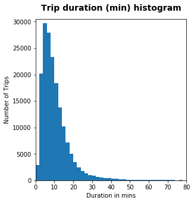

```python
plt.figure(figsize = [10, 5])
base_color = sb.color_palette()[0]
plt.subplot(1, 2, 1)
bin_edges = np.arange(0, fordgobike['duration_min'].max()+3, 2)

plt.hist(fordgobike['duration_min'], bins = bin_edges, color=base_color)
plt.title("Trip duration (min) histogram", y=1.03, fontsize=14, fontweight='semibold')
plt.xlabel('Duration in mins')
plt.ylabel('Number of Trips')
plt.xlim(0, 80)
plt.ylim(0, 30500);
```

It is seen that the peak of the above histogram veers to the left, showing that the distribution of the trip duration is highly skewed to the right (positive skewness), and the trip duration is mostly around 3 to 15 minutes. Further investigation will prove or show whether there is an existing relationship between their ages and the distance covered.

#### 2. At what time of the day pulled more crowd?

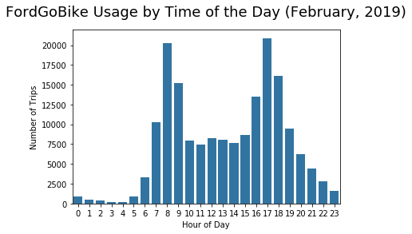

```python
base_color = sb.color_palette()[0]
sb.countplot(data = fordgobike, x = 'start_hour', color = base_color);
plt.xlabel('Hour of Day')
plt.ylabel('Number of Trips')
plt.title('FordGoBike Usage by Time of the Day (February, 2019)', fontsize=18).set_position([.5, 1.05]);
```

Looking at this chart, we can see that the peak of trip visits was usually during rush hour, typically in the morning (between 8 and 9am) and evening (between 4 to 6pm). The top on the list is in the evening at about 5pm (17 hour), followed by 8am (8 hour). This can be explained by the period when people go to work and at the time of return back home. The trend spreaded quite evenly between 10am and 3pm, which indicated working period for many.

#### 3. Which user type frequents the most?

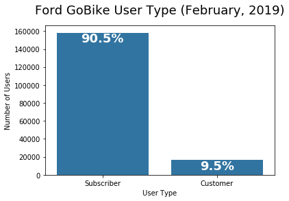

```python
# create the plot
base_color = sb.color_palette()[0]
order = fordgobike['user_type'].value_counts().index
sb.countplot(data = fordgobike, x = 'user_type', color = base_color, order=order)

# add annotations
n_points = fordgobike.shape[0]
cat_counts = fordgobike['user_type'].value_counts()
locs, labels = plt.xticks() # get the current tick locations and labels
plt.xlabel('User Type')
plt.ylabel('Number of Users')
plt.title('Ford GoBike User Type (February, 2019)', fontsize=18).set_position([.5, 1.05]);

# loop through each pair of locations and labels
for loc, label in zip(locs, labels):

    # get the text property for the label to get the correct count
    count = cat_counts[label.get_text()]
    pct_string = '{:0.1f}%'.format(100*count/n_points)

    # print the annotation just below the top of the bar
    plt.text(loc, count-8, pct_string, color = 'w', fontsize=18,
             horizontalalignment='center', verticalalignment='top',fontweight='bold')
```

It is obvious that majority of the users are subscribers, who are registered members, representing 90.5% of the total riders. Customers on the other hand are quite few, representing only 9.5%. This shows that many of the users are frequent users and not visitors within San Francisco Bay area

#### 4. What day and type of the week rented the most?

```
Text(0.5,0,'Type of the Week')
```

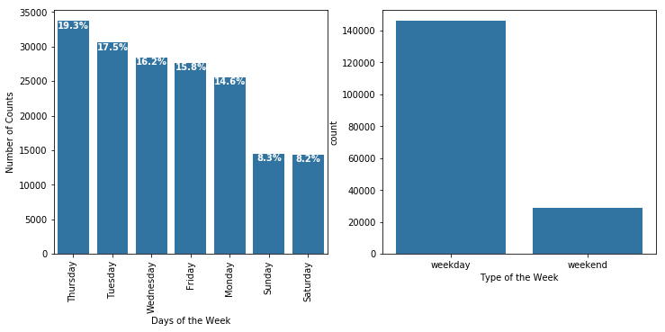

```python
# Vertical bar chart using seaborn, with uniform color and in descreasing order of frequency
# Left chart: What day of the week rented the most?
plt.figure(figsize = [12, 5])
base_color = sb.color_palette()[0]
day_order = fordgobike['day_of_week'].value_counts().index
plt.subplot(1, 2, 1)
sb.countplot(data=fordgobike, x='day_of_week', color=base_color, order=day_order);
plt.xticks(rotation=90)

# add annotations
n_points = fordgobike.shape[0]
cat_counts = fordgobike['day_of_week'].value_counts()
locs, labels = plt.xticks() # get the current tick locations and labels
plt.xlabel('Days of the Week')
plt.ylabel('Number of Counts')

# loop through each pair of locations and labels
for loc, label in zip(locs, labels):

    # get the text property for the label to get the correct count
    count = cat_counts[label.get_text()]
    pct_string = '{:0.1f}%'.format(100*count/n_points)

    # print the annotation just below the top of the bar
    plt.text(loc, count-8, pct_string, color = 'w', fontsize=10,
             horizontalalignment='center', verticalalignment='top',fontweight='bold')

# Vertical bar chart using seaborn, with uniform color
# Right chart: What type of the week rented the most?
plt.subplot(1, 2, 2)
base_color = sb.color_palette()[0]
sb.countplot(data = fordgobike, x = 'week_type', color = base_color);
plt.xlabel('Type of the Week')
```

The satistics above shows that majority of the users travelled most on a Thursday, with about 19.3%, followed by Tuesday (17.5%) and the least travelled was on saturday, being a weekend. Overall, the majority of the travels made was on weekdays with over 80% recorded, while a few travels was made on weekends, less than 20%. The implication of this is that people move around more often on weekdays than weekends mainly because weekdays are working days and they tend to rest more on weekends.

#### 5. What is the statistics of age range distribution?

young_adults: age 18-40 years

older_adults: age 40-70 years

seniors: age 70-80 years

```python
bin_edges = [ 17, 40, 70, 80]
bin_names = ['young_adults', 'older_adults', 'seniors']

# Create age_range column
fordgobike['age_range'] = pd.cut(fordgobike['age'], bin_edges, labels=bin_names)

# Checking for the successful creation of this column
fordgobike['age_range'].value_counts()
```

```
young_adults    138075
older_adults     36302
seniors            383
Name: age_range, dtype: int64
```

```
Text(0.5,1.03,'Age Range of Users')
```

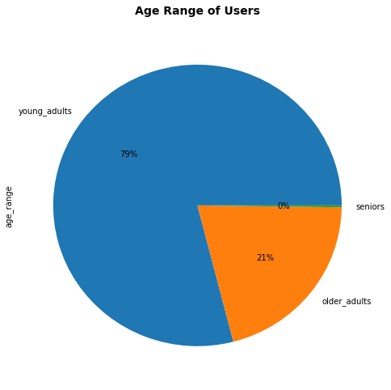

```python
fordgobike.age_range.value_counts().plot(kind='pie', autopct= '%1.0f%%', figsize= (8,8));
plt.title("Age Range of Users", y=1.03, fontsize=14, fontweight='semibold')
```

79% of young adults ages 18-40 years travelled more frequently, followed by the older adults (21%) and the least being seniors above 70 years, with little or no significant presence.

```
Text(0,0.5,'Start Station Names')
```

[figure not shown]

```python
plt.figure(figsize = [10, 5])
location_order = fordgobike['start_station_name'].value_counts()[1:10].index
base_color = sb.color_palette()[1]
plt.subplot(1, 2, 1)
sb.countplot(data=fordgobike, y='start_station_name', color=base_color, order=location_order);
plt.title("Top 10 Most Visited Location", y=1.03, fontsize=14, fontweight='semibold')
plt.xlabel('Number of Counts')
plt.ylabel('Start Station Names')
```

## Bivariate Exploration

#### 1. Is there a relationship between the users age and the distance covered?

```
Text(0,0.5,'Duration in minutes')
```

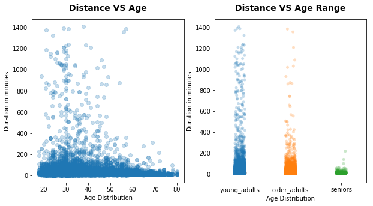

```python
# Left chart: Distance VS Age
plt.figure(figsize = [10, 5])
plt.subplot(1, 2, 1)
sb.regplot(x='age',
            y='duration_min',
            data=fordgobike,
            fit_reg=False,  # do not fit a regression line
            x_jitter=0.1,  # could also dynamically set this with range of data
            y_jitter=0.1,
            scatter_kws={'alpha': 0.25 });
plt.title("Distance VS Age", y=1.03, fontsize=14, fontweight='semibold')
plt.xlabel('Age Distribution')
plt.ylabel('Duration in minutes')


# Right chart: Distance VS Age Range
plt.subplot(1, 2, 2)
sb.stripplot(x=fordgobike["age_range"] , y=fordgobike['duration_min'] , jitter=True ,alpha = 0.25)
plt.title("Distance VS Age Range", y=1.03, fontsize=14, fontweight='semibold')
plt.xlabel('Age Distribution')
plt.ylabel('Duration in minutes')
```

#### 2. What is the proportion of the user's age distribution?

```
Text(0,0.5,'Number of Age Counts')
```

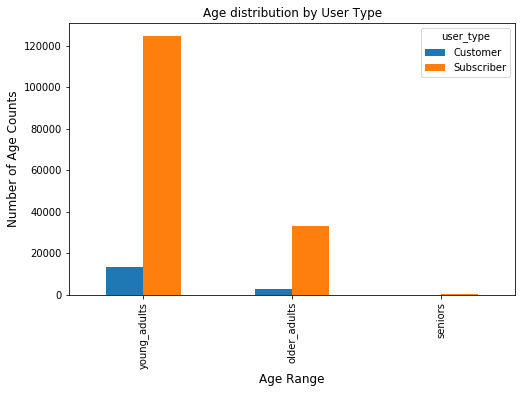

```python
age_distribution= fordgobike.groupby('age_range')['user_type'].value_counts().unstack()
age_distribution.plot(kind='bar', figsize=(8,5), title='Age distribution by User Type');
plt.xlabel('Age Range', fontsize=12)
plt.ylabel('Number of Age Counts', fontsize=12)
```

Apparently, subscribers had the highest population across all age brackets, with the largest of them of over 80% being the young adults ages 18-40 years. Seniors above 70 years had little or no presence.

#### 3. At what duration did each user type travel?

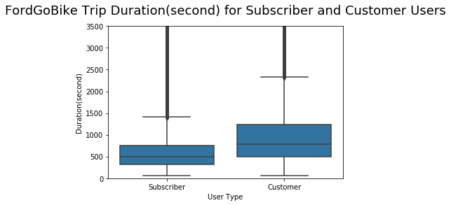

```python
base_color = sb.color_palette()[0]
#order = ['subscriber', 'customer']
order = fordgobike['user_type'].value_counts().index
sb.boxplot(data = fordgobike, x = 'user_type', y = 'duration_sec', color = base_color, order=order);
plt.ylim([0, 3500])
plt.xlabel('User Type')
plt.ylabel('Duration(second)')
plt.title('FordGoBike Trip Duration(second) for Subscriber and Customer Users', fontsize=18).set_position([.5, 1.05]);
```

It can be observed from the box plot that customer users have longer trip duration compared with subscribers, ranging from 500 to 1300 seconds; subscribed users generally have trip duration of 300 to 800 seconds. This might be due to the fact that customers maybe just visitors that chose to tour around the city of San Fransisco, while thhe subscribers are just local travellers that move around a short distance.

#### 4. what is the trend in the number of daily trips from customer and subscriber users?

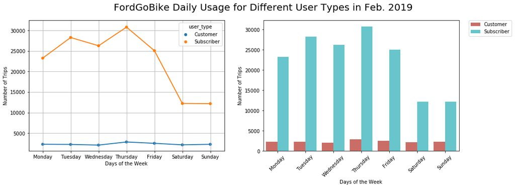

```python
plt.figure(figsize=(16, 5))
plt.subplot(1, 2, 1)
fordgobike_user_week = fordgobike.groupby(['day_of_week', 'user_type']).size().reset_index()
order = ['Monday', 'Tuesday', 'Wednesday','Thursday','Friday','Saturday','Sunday']
ax = sb.pointplot(data=fordgobike_user_week, x='day_of_week',
                  y=0, hue = 'user_type', scale=.7, order = order);
plt.xlabel('Days of the Week')
plt.ylabel('Number of Trips');
plt.grid()


plt.subplot(1, 2, 2)
order = ['Monday', 'Tuesday', 'Wednesday','Thursday','Friday','Saturday','Sunday']
sb.countplot(data = fordgobike, x = 'day_of_week', hue = 'user_type',palette='hls', order= order)
plt.legend(bbox_to_anchor=(1.05, 1), loc=2, borderaxespad=0.)
plt.xlabel('Days of the Week')
plt.ylabel('Number of Trips')
plt.xticks(rotation = 45)
plt.title('FordGoBike Daily Usage for Different User Types in Feb. 2019', fontsize=20).set_position([.00, 1.05]);
```

We can see that users seem to be more active on weekdays (Monday to Friday) than weekends (Saturday and Sunday), with Thursdays topping the list. This trend applies mostly to subscribers. However, the number of trips taken by customers spread quite evenly in each day of week and significantly dropped by over 70% across all days, with little or no difference in trips taken.

#### 5. What is the daily trend in movement between customers and subscribers?

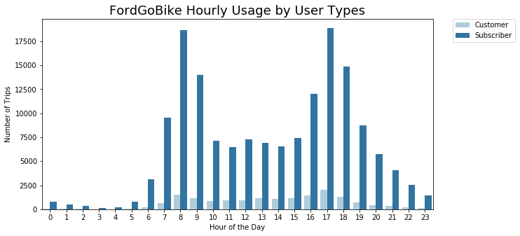

```python
plt.figure(figsize = [10, 5])
sb.countplot(data = fordgobike, x = 'start_hour', hue = 'user_type',palette='Paired')
plt.legend(bbox_to_anchor=(1.05, 1), loc=2, borderaxespad=0.)
plt.xlabel('Hour of the Day')
plt.ylabel('Number of Trips')
plt.xticks(rotation = 0)
plt.title('FordGoBike Hourly Usage by User Types', fontsize=18);
```

The ratio of subscribers and customers travelling on each day is highly significant across all time of the day, with over 80% of subscribers travelling every hour.

## Multivariate Exploration

#### 1. Investigating the weekly trend in ride usage for both Customers and Subscribers

```
Text(767.727,0.5,'Days of the Week')
```

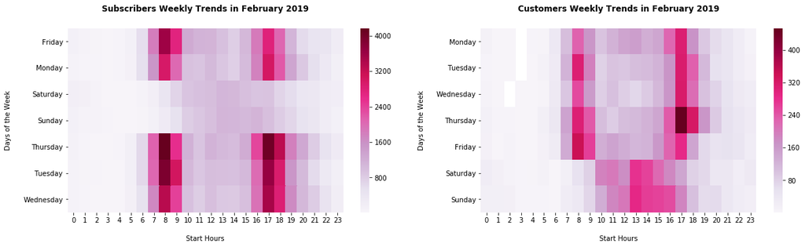

```python
# Left: Heat Map for FordGoBike Subscribers
plt.figure(figsize = [20, 5])
plt.subplot(1, 2, 1)
fordgobike_subscriber = fordgobike.query('user_type == "Subscriber"').groupby(['day_of_week', 'start_hour'])['bike_id'].size().reset_index();
fordgobike_subscriber = fordgobike_subscriber.pivot('day_of_week', 'start_hour', 'bike_id')
hot_maps = sb.heatmap(fordgobike_subscriber, cmap = 'PuRd')
plt.title("Subscribers Weekly Trends in February 2019", y=1.07, fontweight='bold')
plt.xlabel('Start Hours', labelpad = 17)
plt.ylabel('Days of the Week', labelpad = 17);

#Right: # Left: Heat Map for FordGoBikes Customer
plt.subplot(1, 2, 2)
weekday = ['Monday', 'Tuesday', 'Wednesday', 'Thursday', 'Friday', 'Saturday', 'Sunday']
fordgobike['day_of_week'] = pd.Categorical(fordgobike['day_of_week'],
                                                  categories= ['Monday', 'Tuesday', 'Wednesday', 'Thursday', 'Friday', 'Saturday', 'Sunday'], ordered=True);
fordgobike_customer = fordgobike.query('user_type == "Customer"').groupby(['day_of_week', 'start_hour'])['bike_id'].size().reset_index();
fordgobike_customer = fordgobike_customer.pivot('day_of_week', 'start_hour', 'bike_id')
heat_map = sb.heatmap(fordgobike_customer, cmap='PuRd')
plt.title('Customers Weekly Trends in February 2019', y=1.07, fontweight='bold')
plt.xlabel('Start Hours', labelpad = 17)
plt.ylabel('Days of the Week',  labelpad = 17)
```

The above plot shows that customers use the fordgobike sharing system everyday, while the subscribers ride bikes on weekdays from Monday all through to Friday, around 7-9am and 4-6pm. On the weekends, subscribers witnessed a significant drop in the number of rented bikes.

#### 2. What is the relationship between the trip duration and age for subscribers and customers?

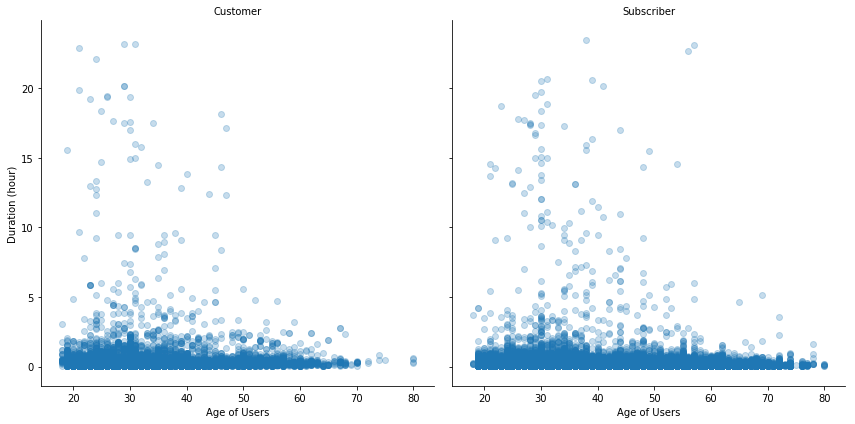

```python
g = sb.FacetGrid(data = fordgobike, col = 'user_type', size = 6, col_wrap = 2)
g.map(plt.scatter, 'age', 'duration_hour', alpha=0.25)
g.set_titles("{col_name}", fontsize=18)
g.set_xlabels('Age of Users')
g.set_ylabels('Duration (hour)');
```

Interestingly, the younger users happened to generate more revenue than the older ones because longer duration means more money. Longer hours up to 20hours ride was observed between ages 18 to 45 years old for both the suscribers and customers, which makes them potential target market. Further user trends will be established for further analysis.

#### 3. This brings us to our next question ... What's the most frequent age range according to user type ? Do younger subscribers take the Bike ride more than Younger customers ? Let's find out

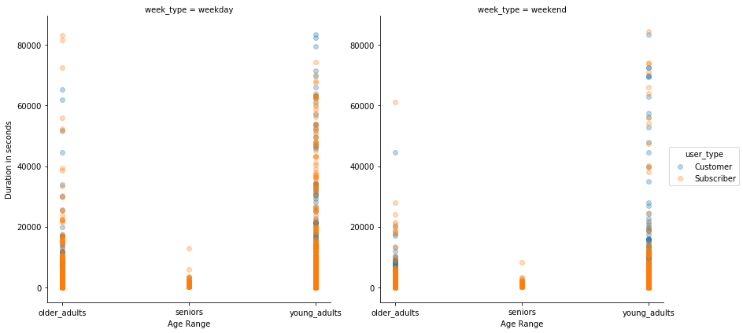

```python
g = sb.FacetGrid(data=fordgobike ,col = 'week_type' , hue = 'user_type', size = 6)
g.map(plt.scatter , 'age_range','duration_sec' , alpha = 0.3).add_legend()
g.set_xlabels('Age Range')
g.set_ylabels('Duration in seconds')
g.set_xticklabels()
plt.show()
```

We can see that this is a confirmation of our previous observation. Users that frequent the most both on weekdays and weekends are around ages 18 to 45 years, and this falls within the young_adults range and are mostly young subscribers.

#### 4. At what time within the week is the peak of sales?

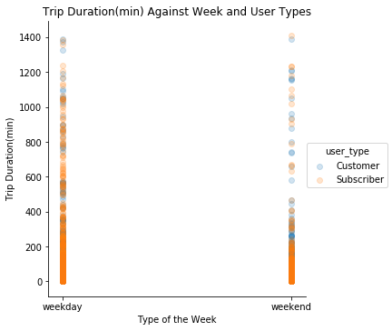

```python
g = sb.FacetGrid(data = fordgobike, hue = 'user_type', size = 5)
g.map(plt.scatter, 'week_type','duration_min', alpha = 0.2)
g.add_legend()
plt.title('Trip Duration(min) Against Week and User Types')
plt.xlabel('Type of the Week')
plt.ylabel('Trip Duration(min)');
```

Apparently, we can see that more sales (longer duration) was recorded on weekdays for the subscribers, and although the customers seem to ride more on weekends, the total population on weekends was significantly lesser. Hence, weekdays remained the lead in terms of revenue generation

#### 5. What trend can be observed between gender duration everyday of the week?

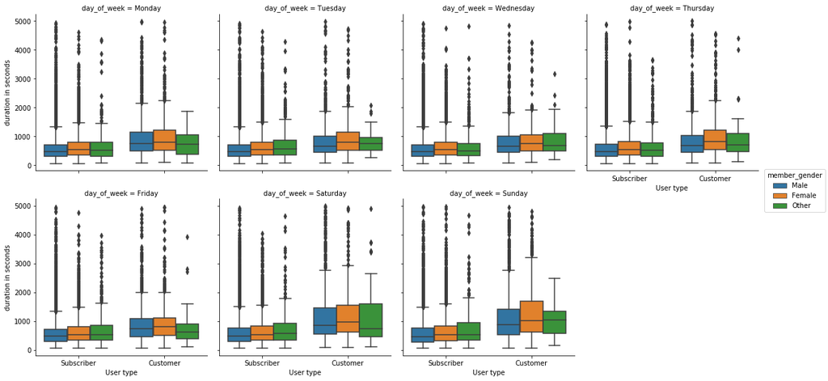

```python
g = sb.factorplot(x="user_type", y="duration_sec",col = 'day_of_week',hue="member_gender",col_wrap=4, kind="box",
                  data=fordgobike.query('duration_sec < 5000'))
g.set_xlabels('User type')
g.set_ylabels('duration in seconds')
plt.show()
```

So far we looked in terms of day and age. We can see that a larger distance was covered on weekends for all genders (male, female and others), but this does not prove the total number of bikers. This may be as a result of people touring the city somewhere far as a way of relaxation or for fun. By referring to the category 'other', these are people that may not want to disclose their gender or were not opportuned to fill that part.

## Conclusions

#### Key Findings in Bivariate Exploration

1. The older the age, the less rides and shorter distance observed
2. Subscribers had the highest population across all age brackets
3. Customer users have longer trip duration compared with subscribers
4. Users were be more active on weekdays than weekends.
5. The ratio of subscribers and customers travelling on each day is highly significant across all time of the day, with over 80% of subscribers travelling every hour.

#### Key Findings in Multivariate Exploration

1. Many users ride bikes mainly on weekdays from Monday all through to Friday, around 7-9am and 4-6pm.
2. The younger ones happened to travel longer, generating more revenue than the older ones. Hence they can be considered as the target audience.
3. Users that frequent the most are ages 18 to 45 years, and this falls within the young_adults range and are mostly young subscribers.
4. Weekdays took the lead in terms of revenue generation
5. Although a larger distance was covered on weekends for all genders (male, female and others), this does not prove the total number of bikers and hence, no reasonable conclusion can be drawn.